# INFORMACION OBTENIDA DE CATASTRO A PARTIR DE LA REFERENCIA CATASTRAL

2022-12-05

Los datos catastrales de un inmueble dan una información gratuita como: la superficie, representación gráfica de las plantas, de la parcela, año de construcción, antigüedad, clase y uso e incluso sus coordenadas.

Con la información de catastro se puede localizar y cartografiar un inmueble y calcular la base imponible de ciertos impuestos como el de los Bienes Inmuebles (IBI).

La referencia catastral es el código alfanumérico único que identifica a cada bien inmueble inequívocamente en la cartografía catastral.

```
[1] "8133302VK1983S0001JE"
```

Una parcela o finca catastral es la unidad básica de suelo para la cartografía catastral y que limita el derecho a la propiedad del titular o los titulares del inmueble.

Hay que distinguir entre los siguientes conceptos:

**- FICHA O CONSULTA CATASTRAL:** La consulta descriptiva y gráfica o ficha catastral es un conjunto de datos públicos sobre todos los bienes inmuebles registrados en España, puede ser consultada en la Sede Virtual de Catastro de forma gratuita.

**- CERTIFICADOS DEL CATASTRO:** Los certificados catastrales son documentos oficiales que acreditan la existencia o inexistencia de ciertos datos catastrales de un bien inmueble frente a un tercero. Tienen una duración anual y existen dos tipos: la certificación catastral descriptiva y gráfica; y la certificación catastral literal.

**- ESTADÍSTICAS CATASTRALES** Las estadísticas son un producto catastral que proporciona información a partir de los datos inscritos en la Dirección General del Catastro, además de estadísticas tributarias sobre el Impuesto de Bienes Inmuebles (IBI).

Además desde la Sede Electrónica de Catastro se ofrecen otro tipo de datos e información, como son: el informe de validación, fotografias aéreas, exportar en distintos formatos conjuntos de coordenadas e incluso se puede modificar los datos catastrales.

Los datos catastrales también son un recurso imprescindible para los tasadores homologados a la hora de obtener el valor de tasación de un inmueble, ya que a partir de la referencia catastral pueden obtener mucha información sobre el predio o suelo a tasar.

#### **INTRODUCIMOS LA REFERENCIA CATASTRAL DEL INMUEBLE: 8133302VK1983S**

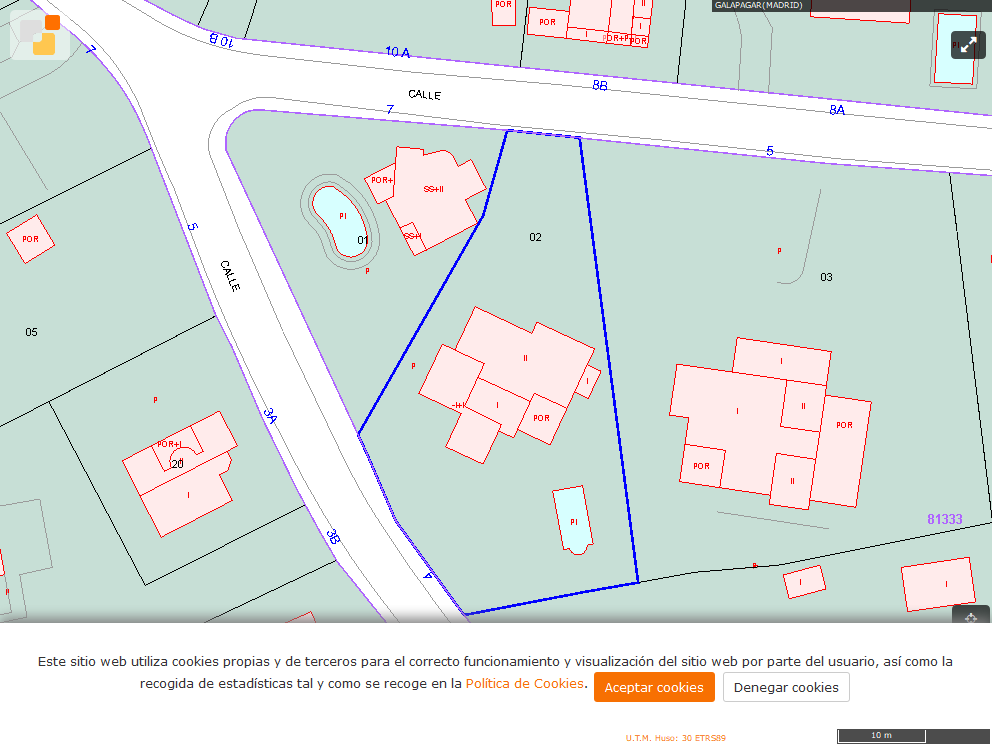

#### **LAS COORDENADAS SON:**

```
         [,1]
xcoord   "-3.969493"
ycoord   "40.58561"
refcat   "8133302VK1983S"
address  "CL CEDROS 4 GALAPAGAR (MADRID)"
pc.pc1   "8133302"
pc.pc2   "VK1983S"
geo.xcen "-3.96949281239831"
geo.ycen "40.5856117678208"
geo.srs  "EPSG:4326"
ldt      "CL CEDROS 4 GALAPAGAR (MADRID)"
```

#### **DATOS DEL MUNICIPIO:**

```
           [,1]
munic      "GALAPAGAR"
catr_to    "28"
catr_munic "061"
catrcode   "28061"
cpro       "28"
cmun       "061"
inecode    "28061"
```

#### **HOJA IMPRIMIBLE DE CATASTRO:**

```
[1] "https://www1.sedecatastro.gob.es/CYCBienInmueble/OVCConCiud.aspx?UrbRus=U&RefC=8133302VK1983S0001JE&esBice=&RCBice1=&RCBice2=&DenoBice=&from=OVCBusqueda&pest=rc&RCCompleta=8133302VK1983S0001JE&final=&del=28&mun=061"
```

[figure not shown]

**Las coordenadas de centroide del inmueble son: -3.969546, 40.5854736**

#### **PLOTEO DE LA CONSTRUCCION Y CENTROIDE SOBRE COORDENADAS**

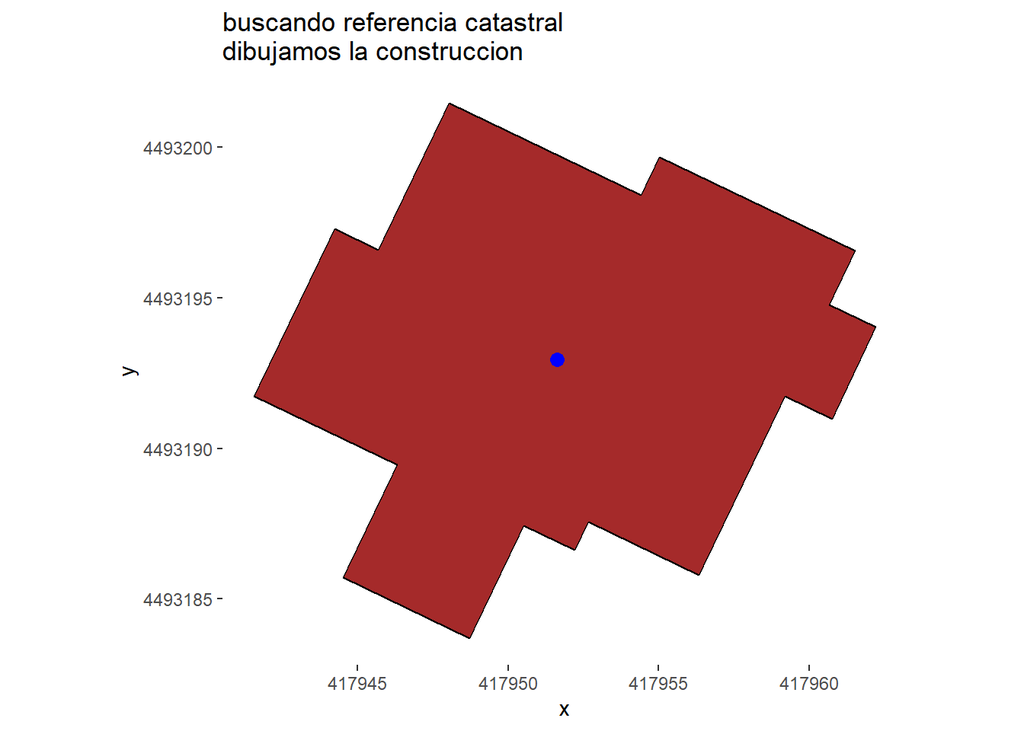

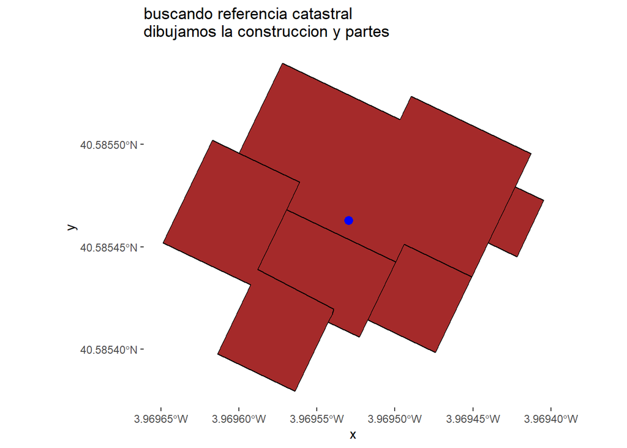

#### **PLOTEO DE LA PARCELA SOBRE COORDENADAS**

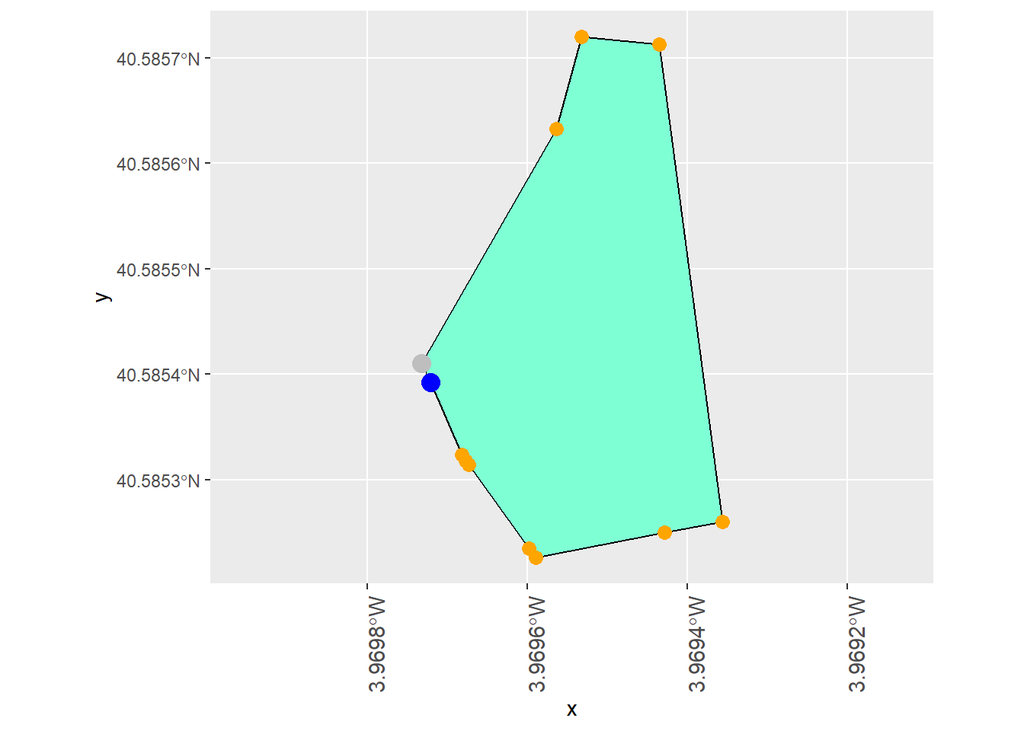

#### **LAS COORDENADAS DE LA PARCELA SON:**

```
           X        Y
1  -3.969721 40.58539
2  -3.969732 40.58541
3  -3.969564 40.58563
4  -3.969532 40.58572
5  -3.969435 40.58571
6  -3.969356 40.58526
7  -3.969429 40.58525
8  -3.969589 40.58523
9  -3.969598 40.58523
10 -3.969673 40.58531
11 -3.969677 40.58532
12 -3.969682 40.58532
13 -3.969721 40.58539
```

#### **GEOREFERENCIACION DE LA PARCELA SEGUN CATASTRO:**

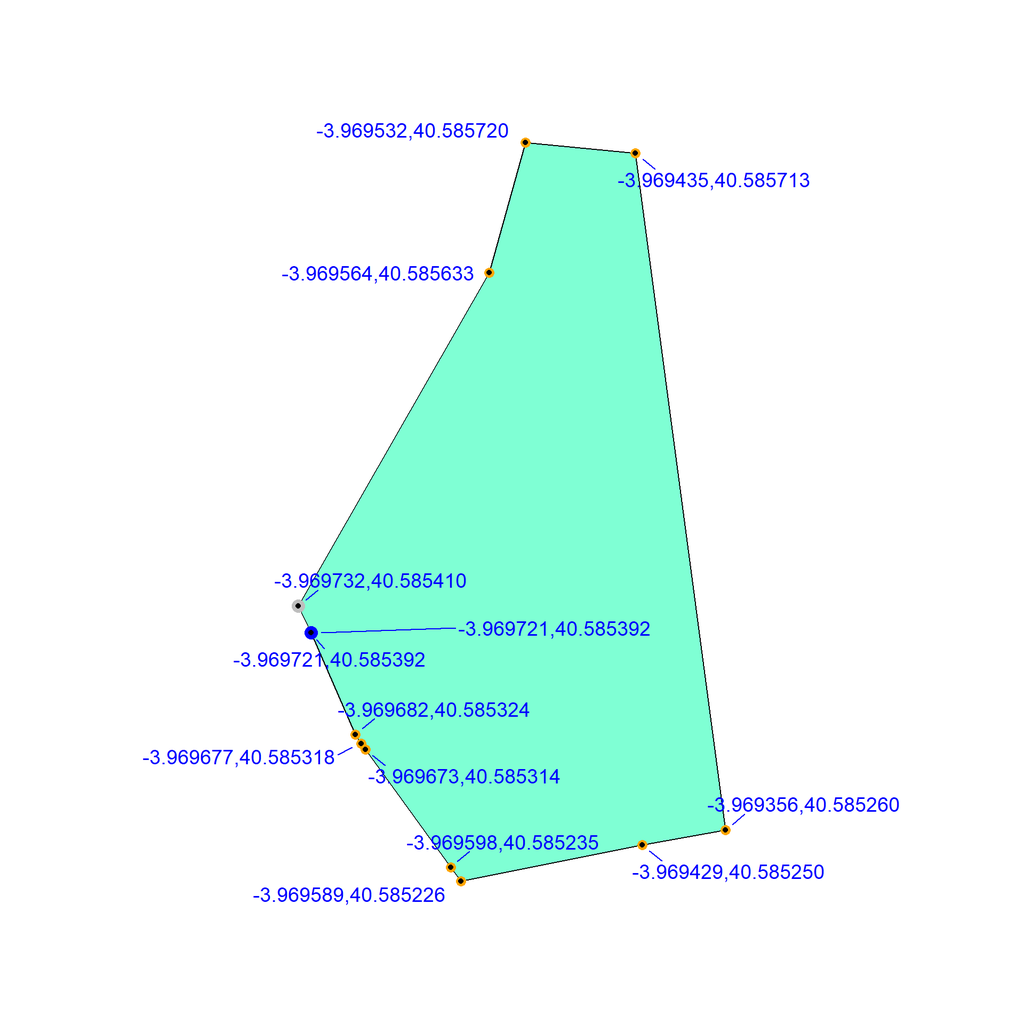

#### **PLOTEO LA EDIFICACION SOBRE COORDENADAS**

```
                                        [,1]
gml_id                                  "ES.SDGC.BU.8133302VK1983S"
beginLifespanVersion                    "2019-07-05T00:00:00"
conditionOfConstruction                 "functional"
beginning                               "1970-01-01T00:00:00"
end                                     "1970-01-01T00:00:00"
endLifespanVersion                      "NA"
informationSystem                       "https://www1.sedecatastro.gob.es/CYCBienInmueble/OVCListaBienes.aspx?rc1=8133302&rc2=VK1983S"
reference                               "8133302VK1983S"
localId                                 "8133302VK1983S"
namespace                               "ES.SDGC.BU"
horizontalGeometryEstimatedAccuracy     0.1
horizontalGeometryEstimatedAccuracy_uom "m"
horizontalGeometryReference             "footPrint"
referenceGeometry                       TRUE
currentUse                              "1_residential"
numberOfBuildingUnits                   1
numberOfDwellings                       1
numberOfFloorsAboveGround               "NA"
documentLink                            "http://ovc.catastro.meh.es/OVCServWeb/OVCWcfLibres/OVCFotoFachada.svc/RecuperarFotoFachadaGet?Refer" [truncated]
format                                  "jpeg"
sourceStatus                            "NotOfficial"
officialAreaReference                   "grossFloorArea"
value                                   377
value_uom                               "m2"
geometry                                POLYGON ((417945.7 4493197,...
```

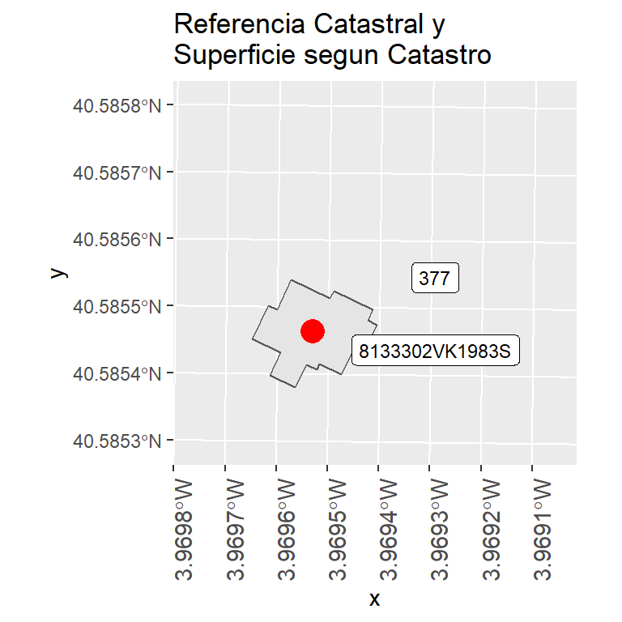

#### **LAS COORDENADAS DE LA EDIFICACION SON:**

```
          X       Y
1  417945.7 4493197
2  417948.0 4493201
3  417954.4 4493198
4  417955.0 4493200
5  417961.5 4493197
6  417960.7 4493195
7  417962.2 4493194
8  417960.8 4493191
9  417959.2 4493192
10 417958.3 4493190
11 417956.3 4493186
12 417952.7 4493188
13 417952.2 4493187
14 417950.5 4493187
15 417948.7 4493184
16 417944.5 4493186
17 417946.3 4493189
18 417941.6 4493192
19 417944.2 4493197
20 417945.7 4493197
```

#### **REPRESENTACION DE LA EDIFICACION INCLUYENDO LAS COORDENADAS:**

El sentido es horario partiendo del punto de color verde, el punto rojo representa al centroide o centro de masas de la construccion

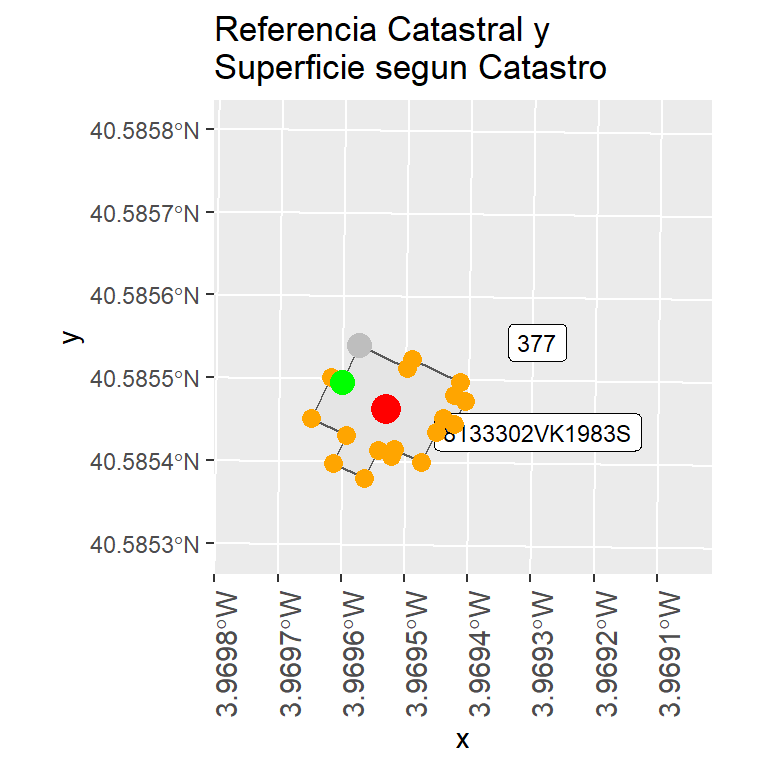

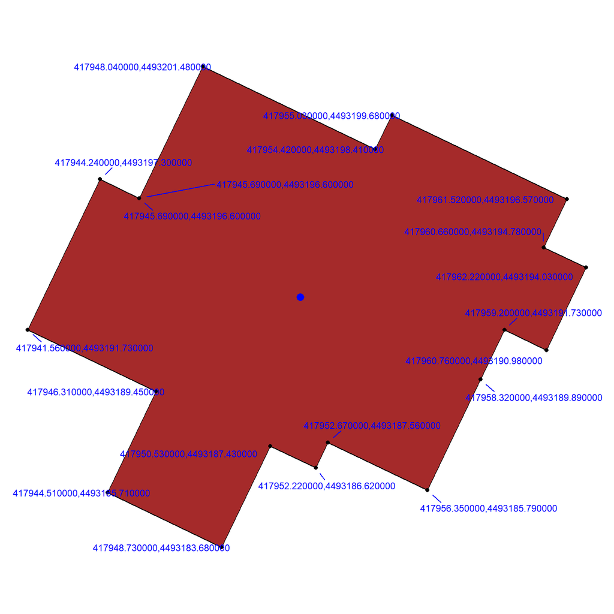

**mostramos la caja de coordenadas de la edificacion**

```
     xmin      ymin      xmax      ymax
 417941.6 4493183.7  417962.2 4493201.5
```

[figure not shown]

#### **FOTO DE CATASTRO DEL INMUEBLE CON SU REFERENCIA CATASTRAL:**

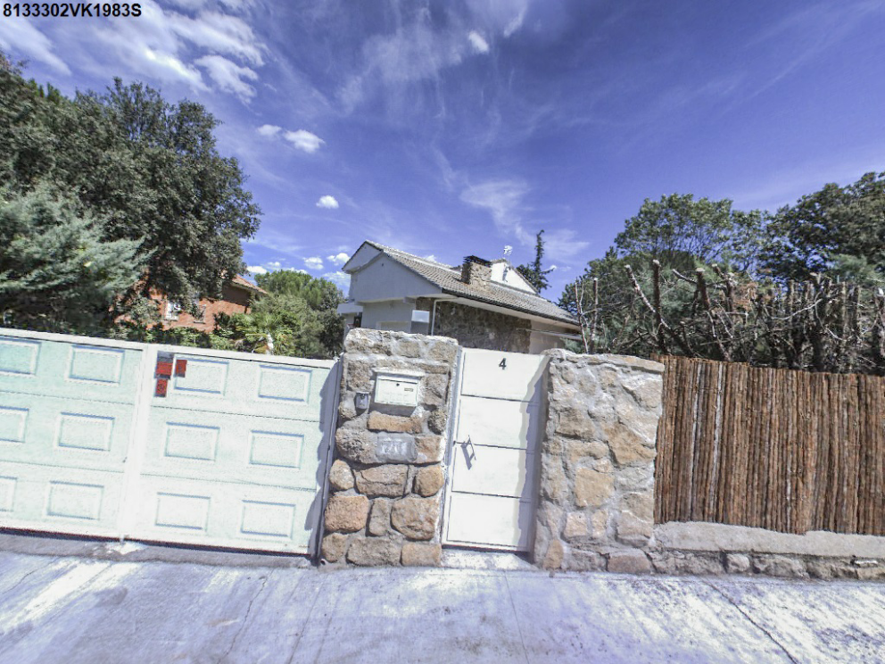

**La web de la foto de la fachada es: http://ovc.catastro.meh.es/OVCServWeb/OVCWcfLibres/OVCFotoFachada.svc/RecuperarFotoFachadaGet?ReferenciaCatastral=8133302VK1983S**

#### **LOS DATOS DE LAS CONSTRUCCIONES DEL CODIGO POSTAL:**

```
[1] "http://www.catastro.minhap.es/INSPIRE/Buildings/28/28061-GALAPAGAR/A.ES.SDGC.BU.28061.zip"
```

```
[1] 7995
```

```
[1] "https://www1.sedecatastro.gob.es/CYCBienInmueble/OVCListaBienes.aspx?rc1=0001001&rc2=00VK19D"
[2] "https://www1.sedecatastro.gob.es/CYCBienInmueble/OVCListaBienes.aspx?rc1=0001002&rc2=00VK19D"
[3] "https://www1.sedecatastro.gob.es/CYCBienInmueble/OVCListaBienes.aspx?rc1=0001003&rc2=00VK19D"
[4] "https://www1.sedecatastro.gob.es/CYCBienInmueble/OVCListaBienes.aspx?rc1=0001005&rc2=00VK19D"
[5] "https://www1.sedecatastro.gob.es/CYCBienInmueble/OVCListaBienes.aspx?rc1=0001006&rc2=00VK19D"
```

```
[1] "https://www1.sedecatastro.gob.es/CYCBienInmueble/OVCListaBienes.aspx?rc1=9132314&rc2=VK1993S"
[2] "https://www1.sedecatastro.gob.es/CYCBienInmueble/OVCListaBienes.aspx?rc1=9132315&rc2=VK1993S"
[3] "https://www1.sedecatastro.gob.es/CYCBienInmueble/OVCListaBienes.aspx?rc1=9132316&rc2=VK1993S"
[4] "https://www1.sedecatastro.gob.es/CYCBienInmueble/OVCListaBienes.aspx?rc1=9132317&rc2=VK1993S"
[5] "https://www1.sedecatastro.gob.es/CYCBienInmueble/OVCListaBienes.aspx?rc1=9133501&rc2=VK1993S"
```

**El numero de edificios del municpio es: 7995**

**La caja del conjunto de las edificaciones es**

```
     xmin      ymin      xmax      ymax
 411870.3 4485115.4  420339.1 4498197.4
```

#### **GRAFICO DE LA EVOLUCION DE CONSTRUCCIONES DEL CODIGO POSTAL:**

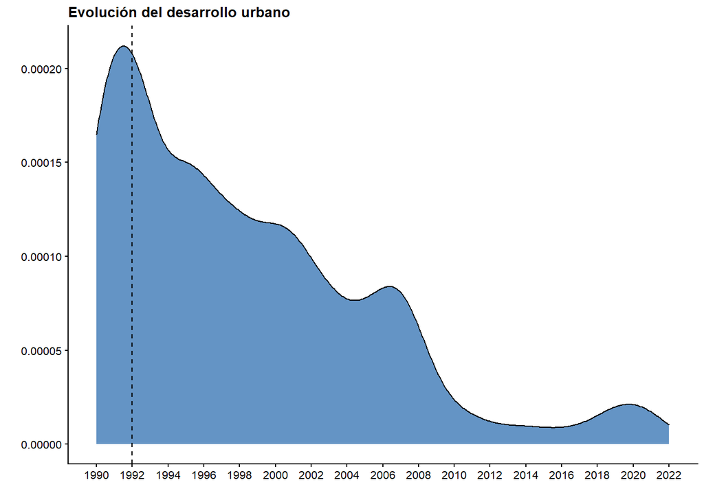

**SE MUESTRA EL NUMERO DE CONSTRUCCIONES DE LOS ULTIMOS 15 AÑOS**

```
   as.numeric(year)  n
19             2008 83
20             2009 36
21             2010 27
22             2011 26
23             2012 13
24             2013 12
25             2014 20
26             2015  9
27             2016 14
28             2017 10
29             2018 21
30             2019 37
31             2020 37
32             2021 34
33             2022 11
```

[figure not shown]

#### **HISTOGRAMA DE LA EVOLUCION DE CONSTRUCCIONES DEL MUNICIPIO:**

[figure not shown]

```
[1] "https://ovc.catastro.meh.es/Cartografia/WMS/ponencia.aspx?del=28&mun=061"
```

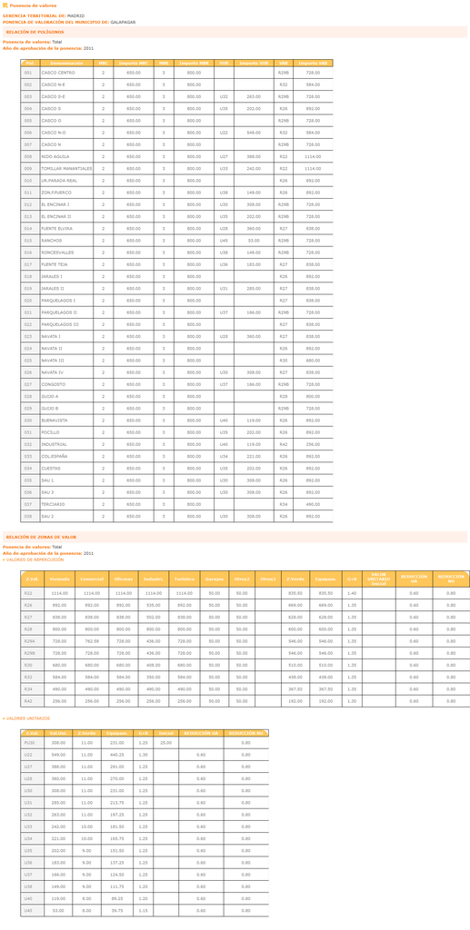